# Gráficos estadísticos con ggplot

Eduardo Marín Nicolalde

eduardo.marin@taryanalytics.com

```r
library(ggplot2)
```

# 1. Histogramas con `geom_histogram`

Como vimos en el taller anterior, un histograma permite representar un conjunto de datos numéricos, con barras (juntas), una vez que los hemos agrupado en intervalos o categorías.

Para ver lo que podemos hacer con la función `ggplot2`, vamos a generar un histograma con la medición de la densidad:

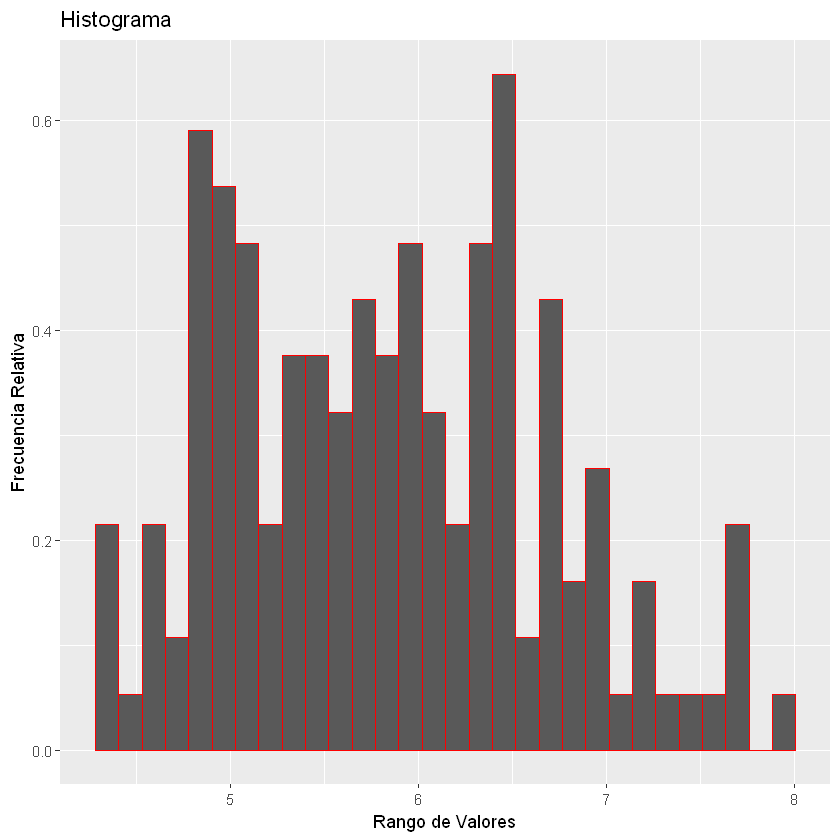

```r
ggplot(data=iris, aes(x=iris$Sepal.Length))+
        geom_histogram(aes(y=..density..), col="red")+
        xlab("Rango de Valores")+
        ylab("Frecuencia Relativa")+
        ggtitle("Histograma")
```

Para ver todas las capacidades de los histogramas con ggplot2, vamos a demostrar el efecto del número de bins o rangos en un histograma:

Para la base de datos `diamonds`, R toma la columna “price” y la segmenta en 30 diferentes unidades o en inglés “bins”. Esto puede conllevar a errores o mal interpretaciones a la hora de estimar la distribucion de los datos:

```r
head(diamonds)
```

| carat | cut | color | clarity | depth | table | price | x | y | z |
| --- | --- | --- | --- | --- | --- | --- | --- | --- | --- |
| 0.23 | Ideal | E | SI2 | 61.5 | 55 | 326 | 3.95 | 3.98 | 2.43 |
| 0.21 | Premium | E | SI1 | 59.8 | 61 | 326 | 3.89 | 3.84 | 2.31 |
| 0.23 | Good | E | VS1 | 56.9 | 65 | 327 | 4.05 | 4.07 | 2.31 |
| 0.29 | Premium | I | VS2 | 62.4 | 58 | 334 | 4.20 | 4.23 | 2.63 |
| 0.31 | Good | J | SI2 | 63.3 | 58 | 335 | 4.34 | 4.35 | 2.75 |
| 0.24 | Very Good | J | VVS2 | 62.8 | 57 | 336 | 3.94 | 3.96 | 2.48 |

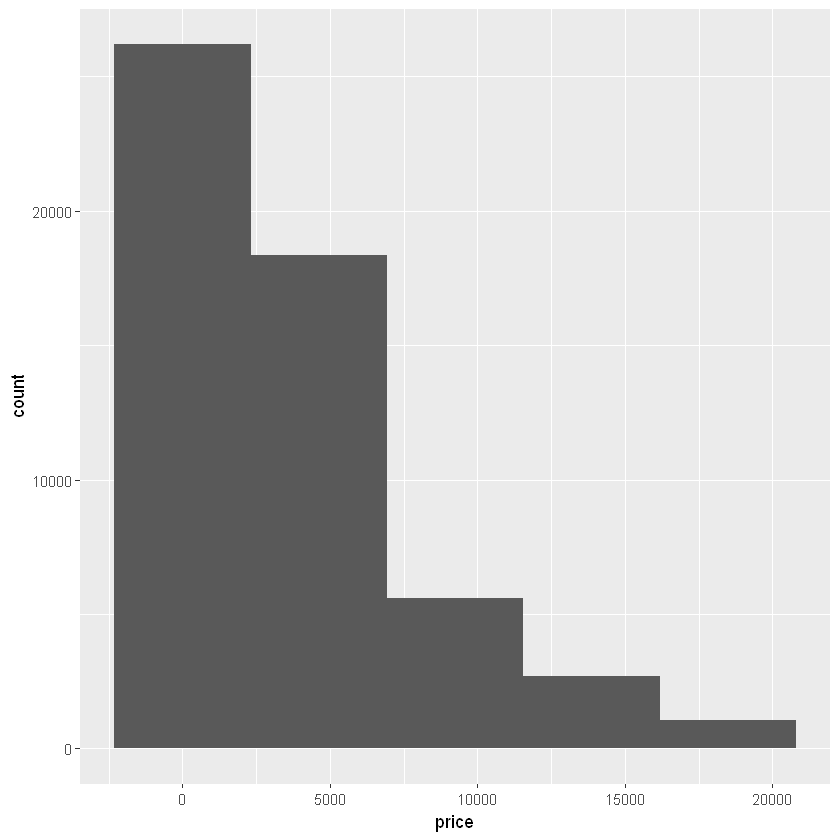

```r
ggplot(diamonds, aes(price)) +
       geom_histogram(bins=5)
```

En casos extremos, se vuelve dificil estimar la distribución de los datos.

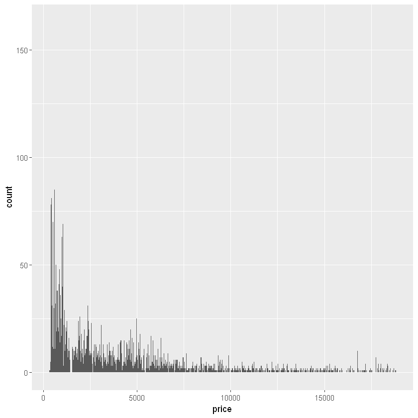

```r
ggplot(diamonds, aes(price)) +
    geom_histogram(bins = 9999)
```

¿Cómo podremos determinar el número exacto de bins que debe presentar un gráfico de histograma?

Una forma es empleando fórmula de Sturges, donde :

$k = 1 + 3.322 $ $log_{10}(n)$

Siendo k el número de bins y n el número de observaciones

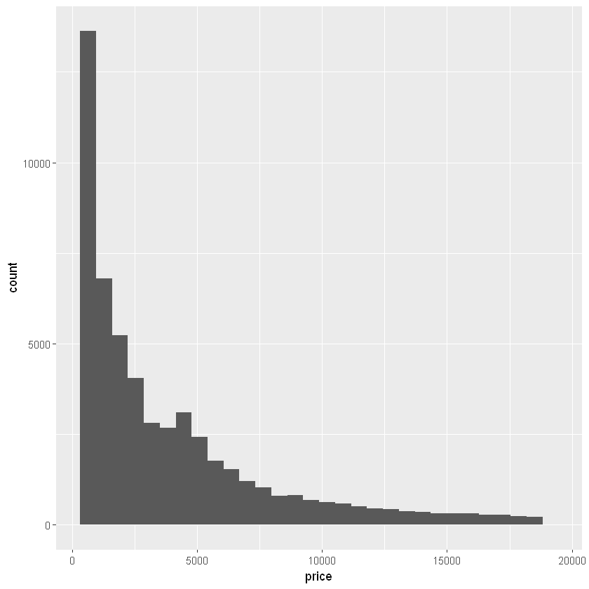

```r
ggplot(diamonds, aes(price)) + geom_histogram(bins = 30)
```

Otra cosa que permite hacer ggplot es generar gráficas de histogramas donde cada “barra” se puede dividir en diferentes elementos que la componen. Utilizamos la columna "cut" para el siguiente gráfico.

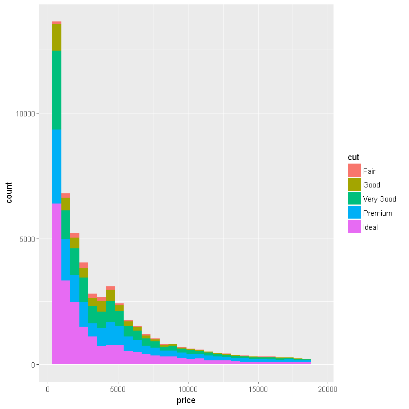

```r
ggplot(diamonds, aes(price, fill = cut)) +
  geom_histogram(position = "stack",bins =30)
```

Adicionalmente ggplot2 permite realizar estimaciones de densidad en 2 dimensiones lo cual puede ser de utilidad para lidear con el sobre ploteo.

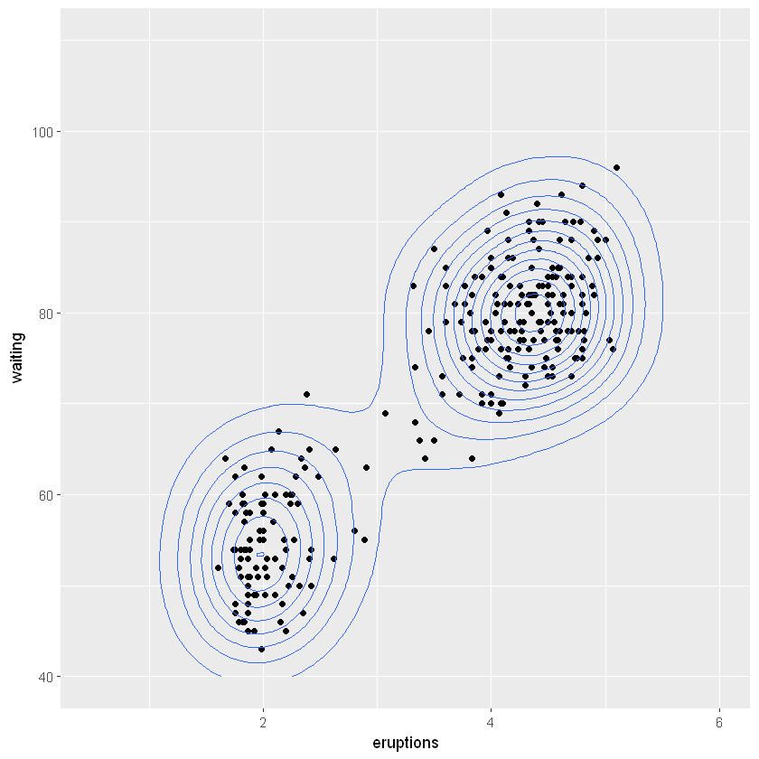

```r
m = ggplot(faithful, aes(x = eruptions, y = waiting)) +
 geom_point() +
 xlim(0.5, 6) +
 ylim(40, 110)

m + geom_density_2d()
```

# Bar plots

Para ver lo diagramas de barras (barplots), en ggplot usaremos los siguientes datos:

```r
months   <- rep(c("jan", "feb", "mar", "apr", "may", "jun",
               "jul", "aug", "sep", "oct", "nov", "dec"), 2)
chickens <- c(1, 2, 3, 3, 3, 4, 5, 4, 3, 4, 2, 2)
eggs     <- c(0, 8, 10, 13, 16, 20, 25, 20, 18, 16, 10, 8)
values   <- c(chickens, eggs)
type     <- c(rep("chickens", 12), rep("eggs", 12))
mydata   <- data.frame(months, values)
```

```r
mydata
```

| months | values |
| --- | --- |
| jan | 1 |
| feb | 2 |
| mar | 3 |
| apr | 3 |
| may | 3 |
| jun | 4 |
| jul | 5 |
| aug | 4 |
| sep | 3 |
| oct | 4 |
| nov | 2 |
| dec | 2 |
| jan | 0 |
| feb | 8 |
| mar | 10 |
| apr | 13 |
| may | 16 |
| jun | 20 |
| jul | 25 |
| aug | 20 |
| sep | 18 |
| oct | 16 |
| nov | 10 |
| dec | 8 |

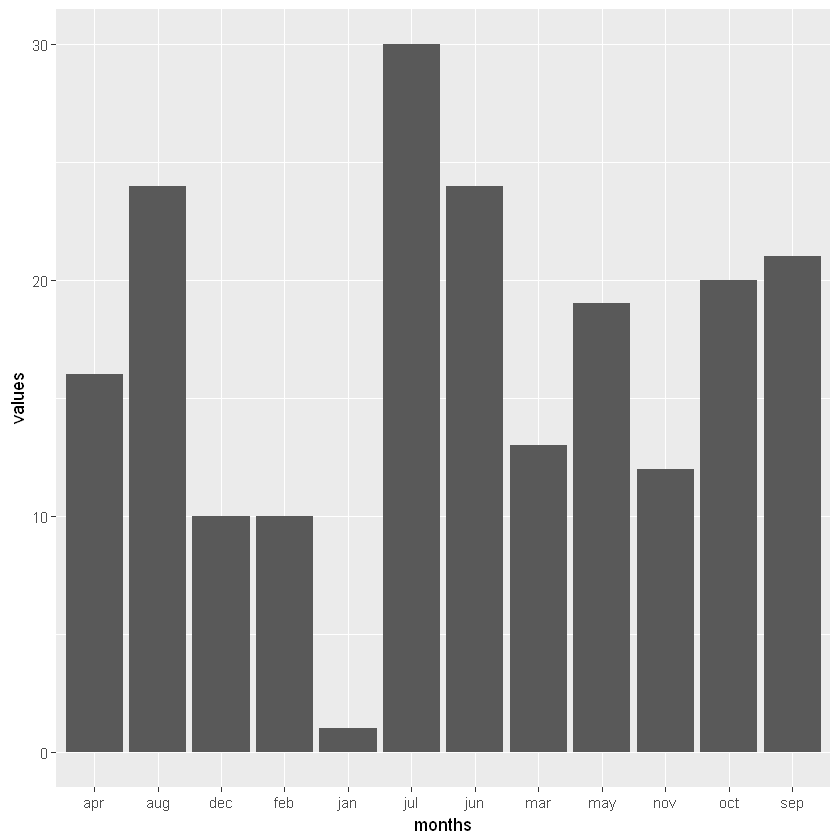

```r
ggplot(mydata, aes(months, values))+
    geom_bar(stat = "identity")
```

```r
mydata$months <-factor(mydata$months,
                      levels = c("jan", "feb", "mar", "apr", "may", "jun",
                                 "jul", "aug", "sep", "oct", "nov", "dec"))
```

Si hacemos que el color de los gráficos se base en la categoría de datos, entonces deberíamos obtener dos conjuntos de columnas. En nuestro marco de datos, colocamos nuestras categorías en la columna llamada "type". El relleno es una propiedad de parcelas de barra. Si estuviéramos haciendo un diagrama de líneas y quisiéramos establecer los colores por tipo de datos, usaríamos color = tipo en lugar de relleno = type.

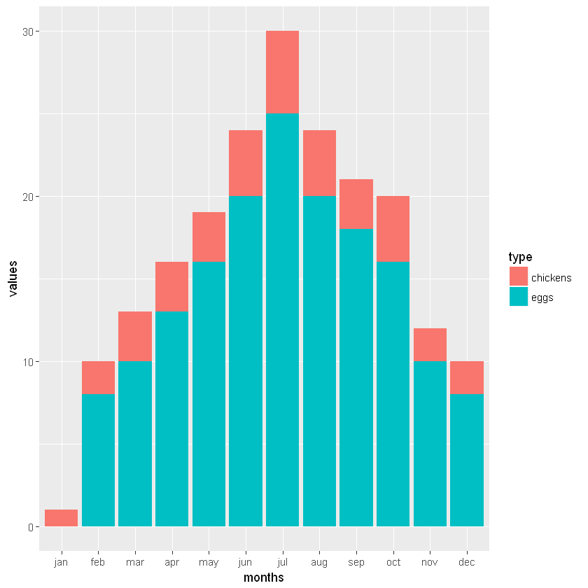

```r
ggplot(mydata, aes(months, values))+
    geom_bar(stat = "identity", aes(fill = type))
```

Si los queremos no apilados sino uno al lado del otro, lo hacemos con el argumento `dodge`.

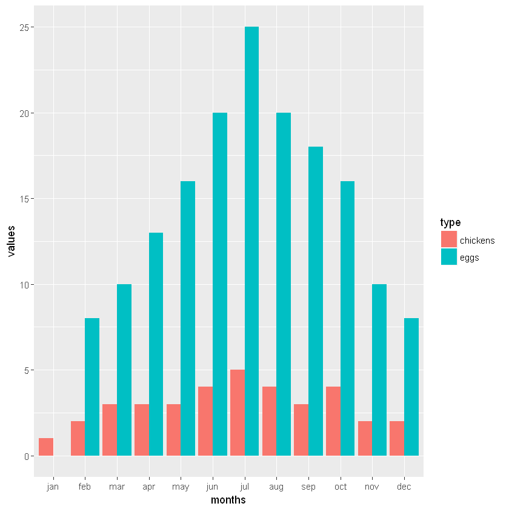

```r
ggplot(mydata, aes(months, values))+
    geom_bar(stat = "identity", aes(fill = type), position = "dodge")
```

Finalmente, ajustar la etiqueta del eje x `(xlab)`, la etiqueta del eje y `(ylab)`, el título `(ggtitle)` y actualizaremos el aspecto con `theme_bw()`:

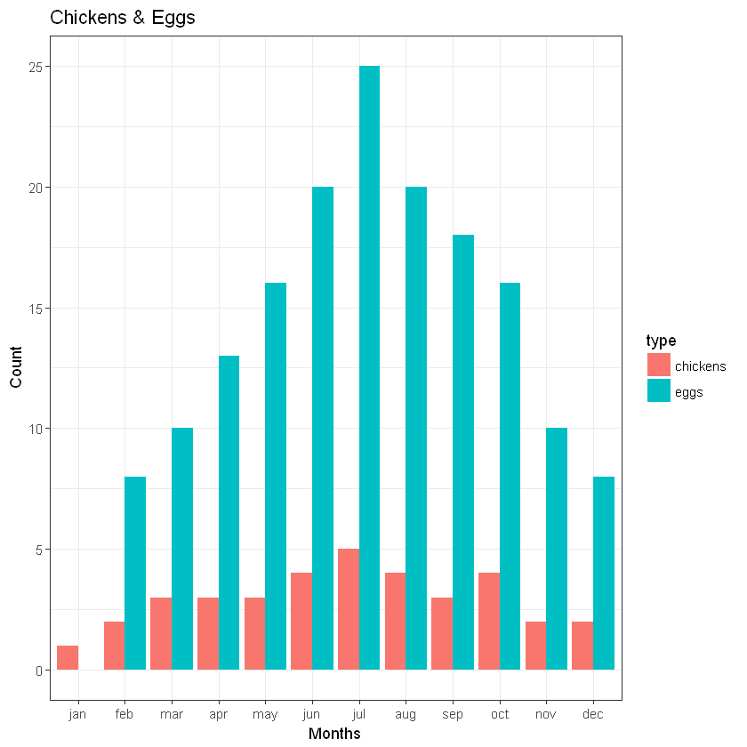

```r
ggplot(mydata, aes(months, values))+
  geom_bar(stat = "identity", aes(fill = type), position = "dodge") +
  xlab("Months") + ylab("Count") +
  ggtitle("Chickens & Eggs") +
  theme_bw()
```

# Scatterplots

Hay muchas maneras de crear un scatterplot en R. la función básica es **plot(x, y)**, donde x y y son vectores numéricos.

```r
data <- LifeCycleSavings[1:10, ]
data
```

|  | sr | pop15 | pop75 | dpi | ddpi |
| --- | --- | --- | --- | --- | --- |
| Australia | 11.43 | 29.35 | 2.87 | 2329.68 | 2.87 |
| Austria | 12.07 | 23.32 | 4.41 | 1507.99 | 3.93 |
| Belgium | 13.17 | 23.80 | 4.43 | 2108.47 | 3.82 |
| Bolivia | 5.75 | 41.89 | 1.67 | 189.13 | 0.22 |
| Brazil | 12.88 | 42.19 | 0.83 | 728.47 | 4.56 |
| Canada | 8.79 | 31.72 | 2.85 | 2982.88 | 2.43 |
| Chile | 0.60 | 39.74 | 1.34 | 662.86 | 2.67 |
| China | 11.90 | 44.75 | 0.67 | 289.52 | 6.51 |
| Colombia | 4.98 | 46.64 | 1.06 | 276.65 | 3.08 |
| Costa Rica | 10.78 | 47.64 | 1.14 | 471.24 | 2.80 |

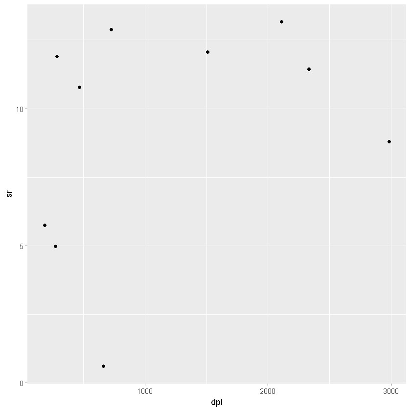

```r
qplot(dpi, sr, data = data)
```

Usar ggplot para etiquetar los puntos del diagrama de dispersión

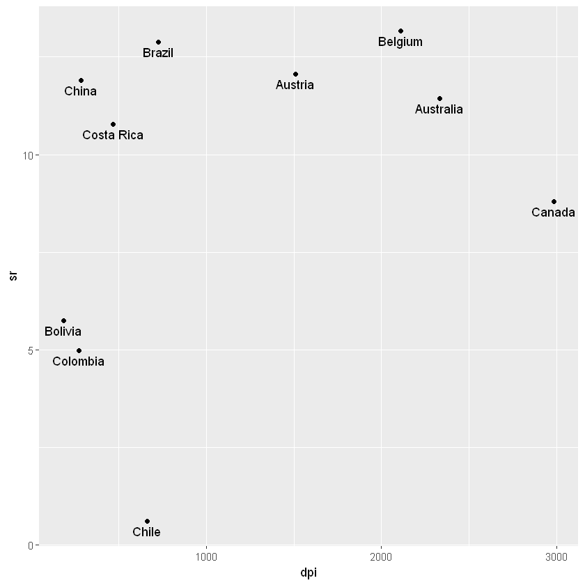

```r
ggplot(data, aes(x = dpi, y = sr, label = rownames(data)))+
    geom_point() +
    geom_text(vjust = 1.5)
```

# Boxplot

El gráfico boxplot permite resumir de manera eficiente distintos índices estadísticos. Para la base de datos `ToothGrowth`:

```r
head(ToothGrowth)
```

| len | supp | dose |
| --- | --- | --- |
| 4.2 | VC | 0.5 |
| 11.5 | VC | 0.5 |
| 7.3 | VC | 0.5 |
| 5.8 | VC | 0.5 |
| 6.4 | VC | 0.5 |
| 10.0 | VC | 0.5 |

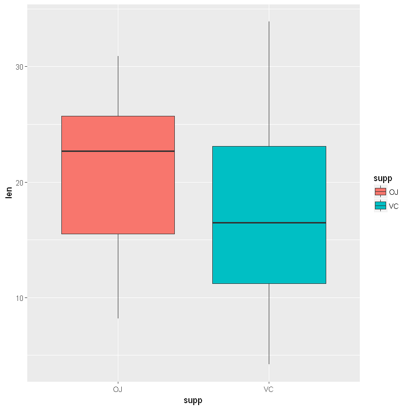

```r
ggplot(ToothGrowth,aes(supp,len)) +
    geom_boxplot(aes(fill=supp))
```

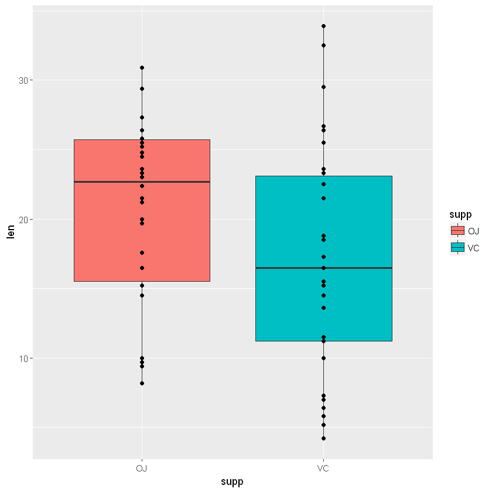

```r
ggplot(ToothGrowth,aes(supp,len)) +
    geom_boxplot(aes(fill=supp))+ geom_point()
```

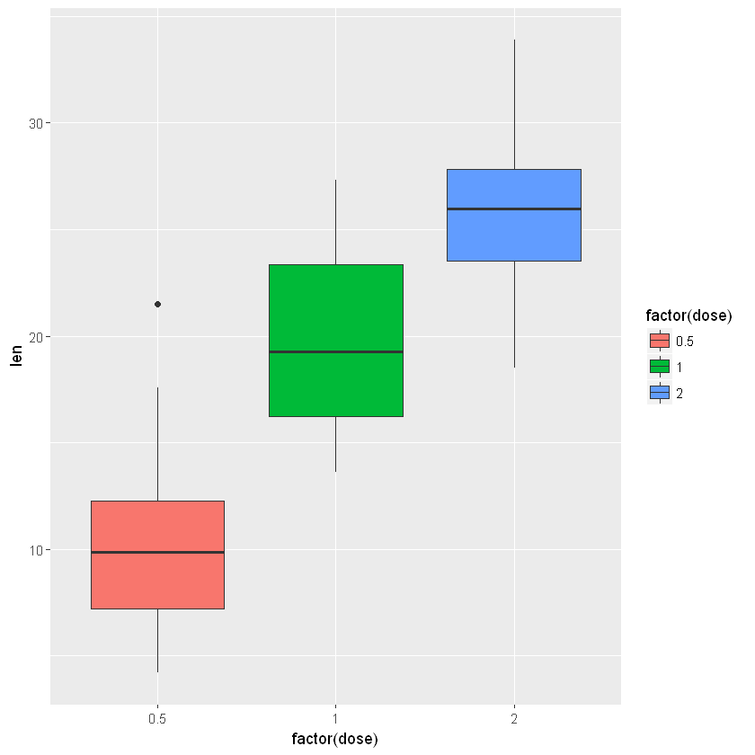

```r
ggplot(ToothGrowth,aes(factor(dose),len)) +
    geom_boxplot(aes(fill=factor(dose)))
```

# Heat map

La función `expand.grid` crea un data.frame de todas las combinaciones de los vectores propuestos

```r
df = expand.grid(teams = c("Team A", "Team B", "Team C", "Team D")
                           ,metrics = c("Metric 1", "Metric 2", "Metric 3", "Metric 4", "Metric 5")
                           )
df
```

| teams | metrics |
| --- | --- |
| Team A | Metric 1 |
| Team B | Metric 1 |
| Team C | Metric 1 |
| Team D | Metric 1 |
| Team A | Metric 2 |
| Team B | Metric 2 |
| Team C | Metric 2 |
| Team D | Metric 2 |
| Team A | Metric 3 |
| Team B | Metric 3 |
| Team C | Metric 3 |
| Team D | Metric 3 |
| Team A | Metric 4 |
| Team B | Metric 4 |
| Team C | Metric 4 |
| Team D | Metric 4 |
| Team A | Metric 5 |
| Team B | Metric 5 |
| Team C | Metric 5 |
| Team D | Metric 5 |

Añadimos una nueva variable proveniende te una distribución normal

```r
set.seed(41)
df$performance = rnorm(nrow(df))
head(df)
```

| teams | metrics | performance |
| --- | --- | --- |
| Team A | Metric 1 | -0.7943683 |
| Team B | Metric 1 | 0.1972575 |
| Team C | Metric 1 | 1.0017043 |
| Team D | Metric 1 | 1.2888254 |
| Team A | Metric 2 | 0.9057534 |
| Team B | Metric 2 | 0.4936675 |

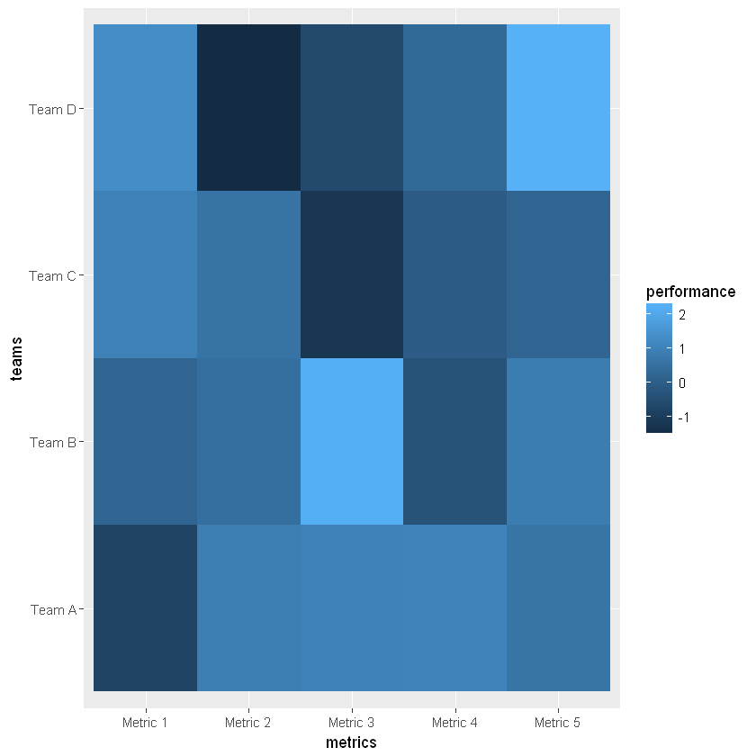

```r
ggplot(data = df, aes(x = metrics, y = teams)) +
    geom_tile(aes(fill = performance))
```